# Data101 Project 2

Praveena Tallapragada

24/06/2019

#### Dataset - LA International Airport Passenger Traffic by Terminal

[Source File](https://catalog.data.gov/dataset/los-angeles-international-airport-passenger-traffic-by-terminal-756ee)

I have selected the “LA International Airport Passenger Traffic by terminal” dataset from Data.gov. This is a simple dataset with 6 variables and 5870 observations. I had selected this dataset for my Project 1 to see if I can know the busiest terminal with respect to the total number of passengers. For my second project, I would like to find any patterns in passenger traffic by gathering the monthly data for Tom Brady International Terminal.

This dataset has the following 6 columns:

1. DataExtractDate
2. ReportPeriod
3. Terminal
4. Arrival_Departure
5. Domestic_International
6. Passenger_Count

#### EDA Principles

##### Formulate your question

I would like to find any patterns in passenger traffic by gathering the monthly data for the year 2018 for one domestic terminal and Tom Brady International Terminal.By observing the passenger traffic on a monthly basis, I hope to find a pattern.

##### Read in your Data

I will be using the following library’s to load, view, clean and plot the data:

```r
library(tidyverse)
library(dplyr)
library(ggplot2)
```

Load the source file from the working directory, get the working directory and ensure the source files is located in this path…

```r
getwd()
```

Load the file in R…

```r
LA_Airport_Source <- read_csv("Los_Angeles_International_Airport_-_Passenger_Traffic_By_Terminal.csv")
```

##### Check the packaging

```r
nrow(LA_Airport_Source)
```

```
## [1] 5870
```

```r
ncol(LA_Airport_Source)
```

```
## [1] 6
```

##### Run str()

```r
str(LA_Airport_Source)
```

```
## Classes 'spec_tbl_df', 'tbl_df', 'tbl' and 'data.frame': 5870 obs. of  6 variables:
##  $ DataExtractDate       : chr  "05/01/2014 12:00:00 AM" "05/01/2014 12:00:00 AM" "05/01/2014 12:00:00 AM" "05/01/2014 12:00:00 AM" ...
##  $ ReportPeriod          : chr  "01/01/2006 12:00:00 AM" "01/01/2006 12:00:00 AM" "01/01/2006 12:00:00 AM" "01/01/2006 12:00:00 AM" ...
##  $ Terminal              : chr  "Imperial Terminal" "Imperial Terminal" "Misc. Terminal" "Misc. Terminal" ...
##  $ Arrival_Departure     : chr  "Arrival" "Departure" "Arrival" "Departure" ...
##  $ Domestic_International: chr  "Domestic" "Domestic" "Domestic" "Domestic" ...
##  $ Passenger_Count       : num  490 498 753 688 401535 ...
##  - attr(*, "spec")=
##   .. cols(
##   ..   DataExtractDate = col_character(),
##   ..   ReportPeriod = col_character(),
##   ..   Terminal = col_character(),
##   ..   Arrival_Departure = col_character(),
##   ..   Domestic_International = col_character(),
##   ..   Passenger_Count = col_double()
##   .. )
```

##### Look at the top and the bottom of your data

```r
head(LA_Airport_Source[, c(2:6)],10)
```

```
## # A tibble: 10 x 5
##    ReportPeriod  Terminal Arrival_Departu… Domestic_Intern… Passenger_Count
##    <chr>         <chr>    <chr>            <chr>                      <dbl>
##  1 01/01/2006 1… Imperia… Arrival          Domestic                     490
##  2 01/01/2006 1… Imperia… Departure        Domestic                     498
##  3 01/01/2006 1… Misc. T… Arrival          Domestic                     753
##  4 01/01/2006 1… Misc. T… Departure        Domestic                     688
##  5 01/01/2006 1… Termina… Arrival          Domestic                  401535
##  6 01/01/2006 1… Termina… Departure        Domestic                  389745
##  7 01/01/2006 1… Termina… Departure        International                561
##  8 01/01/2006 1… Termina… Arrival          Domestic                   98991
##  9 01/01/2006 1… Termina… Arrival          International             163067
## 10 01/01/2006 1… Termina… Departure        Domestic                   93672
```

```r
tail(LA_Airport_Source[, c(2:6)],10)
```

```
## # A tibble: 10 x 5
##    ReportPeriod  Terminal Arrival_Departu… Domestic_Intern… Passenger_Count
##    <chr>         <chr>    <chr>            <chr>                      <dbl>
##  1 03/01/2019 1… Termina… Departure        Domestic                  367998
##  2 03/01/2019 1… Termina… Departure        International              40493
##  3 03/01/2019 1… Termina… Arrival          Domestic                  144933
##  4 03/01/2019 1… Termina… Arrival          International               2132
##  5 03/01/2019 1… Termina… Departure        Domestic                  141931
##  6 03/01/2019 1… Termina… Departure        International               5225
##  7 03/01/2019 1… Tom Bra… Arrival          Domestic                    5066
##  8 03/01/2019 1… Tom Bra… Arrival          International             687288
##  9 03/01/2019 1… Tom Bra… Departure        Domestic                   24976
## 10 03/01/2019 1… Tom Bra… Departure        International             657435
```

#### Cleaning and preparing data with dplyr

Source file contains data from January 2006 to March 2019. For every terminal, we have passenger counts for arrival or departure and whether it is domestic or international.

“DataExtractDate” and “ReportPeriod” are stored as characters instead of a date time variable. Also the time indicated in the variable ‘Reportperiod’ is always defaulted to ‘12:00:00 AM’ and therefore it will not be of any use. I will have to remove it and maybe split the ‘ReportPeriod’ date into month and year to better understand the passenger traffic and find any patters if possible. I will remove ‘DataExtractData’ as I am not interested in knowing when the data was collected for this project.

To undertsand the data in the next three columns - “Terminal”,“Arrival_Departure” and “Domestic_International”, I will get the unique list from these columns.

```r
unique(LA_Airport_Source$Terminal)
```

```
##  [1] "Imperial Terminal"
##  [2] "Misc. Terminal"
##  [3] "Terminal 1"
##  [4] "Terminal 2"
##  [5] "Terminal 3"
##  [6] "Terminal 4"
##  [7] "Terminal 5"
##  [8] "Terminal 6"
##  [9] "Terminal 7"
## [10] "Terminal 8"
## [11] "Tom Bradley International Terminal"
```

```r
unique(LA_Airport_Source$Arrival_Departure)
```

```
## [1] "Arrival"   "Departure"
```

```r
unique(LA_Airport_Source$Domestic_International)
```

```
## [1] "Domestic"      "International"
```

The three variables are categorical and hence it would be better to change the datatype to factor for all three of them.

Now lets check the range of passenger count, just to have an idea of number of passengers.

```r
range(LA_Airport_Source$Passenger_Count)
```

```
## [1]      1 889348
```

Check for NA’s and complete cases

```r
which(is.na(LA_Airport_Source))
```

```
## integer(0)
```

```r
which(!complete.cases(LA_Airport_Source))
```

```
## integer(0)
```

Remove “DataExtractDate” column

```r
LA_Airport_Modified <- LA_Airport_Source %>% select(ReportPeriod,Terminal,Arrival_Departure,Domestic_International,Passenger_Count)

LA_Airport_Modified
```

```
## # A tibble: 5,870 x 5
##    ReportPeriod  Terminal Arrival_Departu… Domestic_Intern… Passenger_Count
##    <chr>         <chr>    <chr>            <chr>                      <dbl>
##  1 01/01/2006 1… Imperia… Arrival          Domestic                     490
##  2 01/01/2006 1… Imperia… Departure        Domestic                     498
##  3 01/01/2006 1… Misc. T… Arrival          Domestic                     753
##  4 01/01/2006 1… Misc. T… Departure        Domestic                     688
##  5 01/01/2006 1… Termina… Arrival          Domestic                  401535
##  6 01/01/2006 1… Termina… Departure        Domestic                  389745
##  7 01/01/2006 1… Termina… Departure        International                561
##  8 01/01/2006 1… Termina… Arrival          Domestic                   98991
##  9 01/01/2006 1… Termina… Arrival          International             163067
## 10 01/01/2006 1… Termina… Departure        Domestic                   93672
## # … with 5,860 more rows
```

Split the “ReportPeriod” column and remove the time.Remove data for the year 2019 as it is incomplete.

```r
LA_Airport_Modified$ReportPeriod <-  as.Date(LA_Airport_Modified$ReportPeriod, "%m/%d/%Y")

LA_Airport_Modified <- LA_Airport_Modified %>%
  mutate(Year = format(ReportPeriod, "%Y"),Month = format(ReportPeriod, "%m"))

LA_Airport_Modified$Year <- as.numeric(LA_Airport_Modified$Year)

LA_Airport_Modified$Month <- as.numeric(LA_Airport_Modified$Month)

LA_Airport_Modified
```

```
## # A tibble: 5,870 x 7
##    ReportPeriod Terminal Arrival_Departu… Domestic_Intern… Passenger_Count
##    <date>       <chr>    <chr>            <chr>                      <dbl>
##  1 2006-01-01   Imperia… Arrival          Domestic                     490
##  2 2006-01-01   Imperia… Departure        Domestic                     498
##  3 2006-01-01   Misc. T… Arrival          Domestic                     753
##  4 2006-01-01   Misc. T… Departure        Domestic                     688
##  5 2006-01-01   Termina… Arrival          Domestic                  401535
##  6 2006-01-01   Termina… Departure        Domestic                  389745
##  7 2006-01-01   Termina… Departure        International                561
##  8 2006-01-01   Termina… Arrival          Domestic                   98991
##  9 2006-01-01   Termina… Arrival          International             163067
## 10 2006-01-01   Termina… Departure        Domestic                   93672
## # … with 5,860 more rows, and 2 more variables: Year <dbl>, Month <dbl>
```

```r
LA_Airport_Mod <-  LA_Airport_Modified %>%
filter(Year !=  2019)

LA_Airport_Mod
```

```
## # A tibble: 5,755 x 7
##    ReportPeriod Terminal Arrival_Departu… Domestic_Intern… Passenger_Count
##    <date>       <chr>    <chr>            <chr>                      <dbl>
##  1 2006-01-01   Imperia… Arrival          Domestic                     490
##  2 2006-01-01   Imperia… Departure        Domestic                     498
##  3 2006-01-01   Misc. T… Arrival          Domestic                     753
##  4 2006-01-01   Misc. T… Departure        Domestic                     688
##  5 2006-01-01   Termina… Arrival          Domestic                  401535
##  6 2006-01-01   Termina… Departure        Domestic                  389745
##  7 2006-01-01   Termina… Departure        International                561
##  8 2006-01-01   Termina… Arrival          Domestic                   98991
##  9 2006-01-01   Termina… Arrival          International             163067
## 10 2006-01-01   Termina… Departure        Domestic                   93672
## # … with 5,745 more rows, and 2 more variables: Year <dbl>, Month <dbl>
```

```r
str(LA_Airport_Mod)
```

```
## Classes 'spec_tbl_df', 'tbl_df', 'tbl' and 'data.frame': 5755 obs. of  7 variables:
##  $ ReportPeriod          : Date, format: "2006-01-01" "2006-01-01" ...
##  $ Terminal              : chr  "Imperial Terminal" "Imperial Terminal" "Misc. Terminal" "Misc. Terminal" ...
##  $ Arrival_Departure     : chr  "Arrival" "Departure" "Arrival" "Departure" ...
##  $ Domestic_International: chr  "Domestic" "Domestic" "Domestic" "Domestic" ...
##  $ Passenger_Count       : num  490 498 753 688 401535 ...
##  $ Year                  : num  2006 2006 2006 2006 2006 ...
##  $ Month                 : num  1 1 1 1 1 1 1 1 1 1 ...
```

Make the variables - “Terminal”,“Arrival_Departure” and “Domestic_International” as factors and try to spread them if needed.Replace space from Terminal names with underscroes.

```r
LA_Airport_Mod$Terminal <- gsub("\\s+","_",LA_Airport_Mod$Terminal)

LA_Airport_Mod$Terminal <- as.factor(LA_Airport_Mod$Terminal)

LA_Airport_Mod$Arrival_Departure <- as.factor(LA_Airport_Mod$Arrival_Departure)

LA_Airport_Mod$Domestic_International <- as.factor(LA_Airport_Mod$Domestic_International)

summary(LA_Airport_Mod)
```

```
##   ReportPeriod              Terminal    Arrival_Departure
##  Min.   :2006-01-01   Terminal_2: 624   Arrival  :2835
##  1st Qu.:2009-04-01   Terminal_5: 624   Departure:2920
##  Median :2012-07-01   Terminal_7: 624
##  Mean   :2012-06-28   Terminal_4: 623
##  3rd Qu.:2015-10-01   Terminal_6: 621
##  Max.   :2018-12-01   Terminal_8: 600
##                       (Other)   :2039
##    Domestic_International Passenger_Count       Year          Month
##  Domestic     :3116       Min.   :     1   Min.   :2006   Min.   : 1.000
##  International:2639       1st Qu.: 19423   1st Qu.:2009   1st Qu.: 3.000
##                           Median :105012   Median :2012   Median : 6.000
##                           Mean   :154558   Mean   :2012   Mean   : 6.489
##                           3rd Qu.:270620   3rd Qu.:2015   3rd Qu.: 9.000
##                           Max.   :889348   Max.   :2018   Max.   :12.000
##
```

Calculate the sum of passenger counts per terminal per year per month.

```r
Monthwise_Data <- LA_Airport_Mod %>%
  select(Terminal,Year,Month,Passenger_Count) %>%
  group_by(Terminal,Year,Month) %>%
  summarize(Passenger_sum = sum(Passenger_Count)) %>%
arrange(desc(Passenger_sum))

Monthwise_Data
```

```
## # A tibble: 1,607 x 4
## # Groups:   Terminal, Year [141]
##    Terminal                            Year Month Passenger_sum
##    <fct>                              <dbl> <dbl>         <dbl>
##  1 Tom_Bradley_International_Terminal  2018     7       1732646
##  2 Tom_Bradley_International_Terminal  2017     7       1704582
##  3 Tom_Bradley_International_Terminal  2018     8       1678943
##  4 Tom_Bradley_International_Terminal  2017     8       1661321
##  5 Tom_Bradley_International_Terminal  2018     6       1622010
##  6 Tom_Bradley_International_Terminal  2017     6       1557537
##  7 Tom_Bradley_International_Terminal  2018     5       1524485
##  8 Tom_Bradley_International_Terminal  2018     1       1462047
##  9 Tom_Bradley_International_Terminal  2018    10       1461613
## 10 Tom_Bradley_International_Terminal  2018    12       1438957
## # … with 1,597 more rows
```

```r
D_I_perM <- LA_Airport_Mod %>%
  select(Domestic_International,Year,Month,Passenger_Count) %>%
  group_by(Domestic_International,Month) %>%
  summarize(Passenger_sum = sum(Passenger_Count)) %>%
  arrange(desc(Passenger_sum))

D_I_perM
```

```
## # A tibble: 24 x 3
## # Groups:   Domestic_International [2]
##    Domestic_International Month Passenger_sum
##    <fct>                  <dbl>         <dbl>
##  1 Domestic                   7      61906670
##  2 Domestic                   8      60324368
##  3 Domestic                   6      58788905
##  4 Domestic                   5      55125367
##  5 Domestic                  12      53722757
##  6 Domestic                  10      53644848
##  7 Domestic                   3      53351960
##  8 Domestic                   4      52372982
##  9 Domestic                  11      51118509
## 10 Domestic                   9      50308403
## # … with 14 more rows
```

#### ggplot2 - Plots

BoxPlot

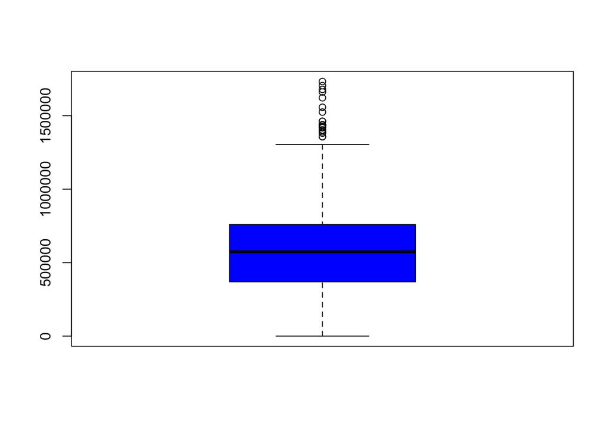

```r
 boxplot(Monthwise_Data$Passenger_sum, col = "blue")
```

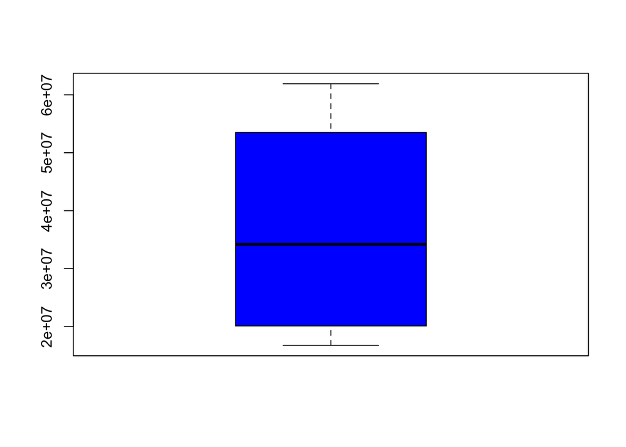

```r
 boxplot(D_I_perM$Passenger_sum, col = "blue")
```

Histogram

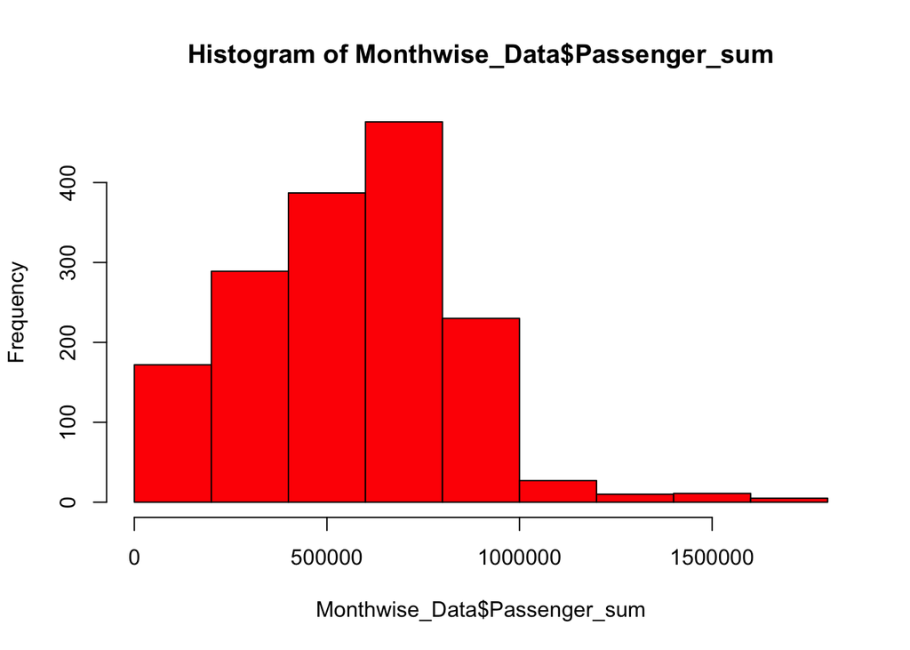

```r
hist(Monthwise_Data$Passenger_sum, col = "red")
```

Scatterplot

```r
str(D_I_perM)
```

```
## Classes 'grouped_df', 'tbl_df', 'tbl' and 'data.frame':  24 obs. of  3 variables:
##  $ Domestic_International: Factor w/ 2 levels "Domestic","International": 1 1 1 1 1 1 1 1 1 1 ...
##  $ Month                 : num  7 8 6 5 12 10 3 4 11 9 ...
##  $ Passenger_sum         : num  61906670 60324368 58788905 55125367 53722757 ...
##  - attr(*, "groups")=Classes 'tbl_df', 'tbl' and 'data.frame':   2 obs. of  2 variables:
##   ..$ Domestic_International: Factor w/ 2 levels "Domestic","International": 1 2
##   ..$ .rows                 :List of 2
##   .. ..$ : int  1 2 3 4 5 6 7 8 9 10 ...
##   .. ..$ : int  13 14 15 16 17 18 19 20 21 22 ...
##   ..- attr(*, ".drop")= logi TRUE
```

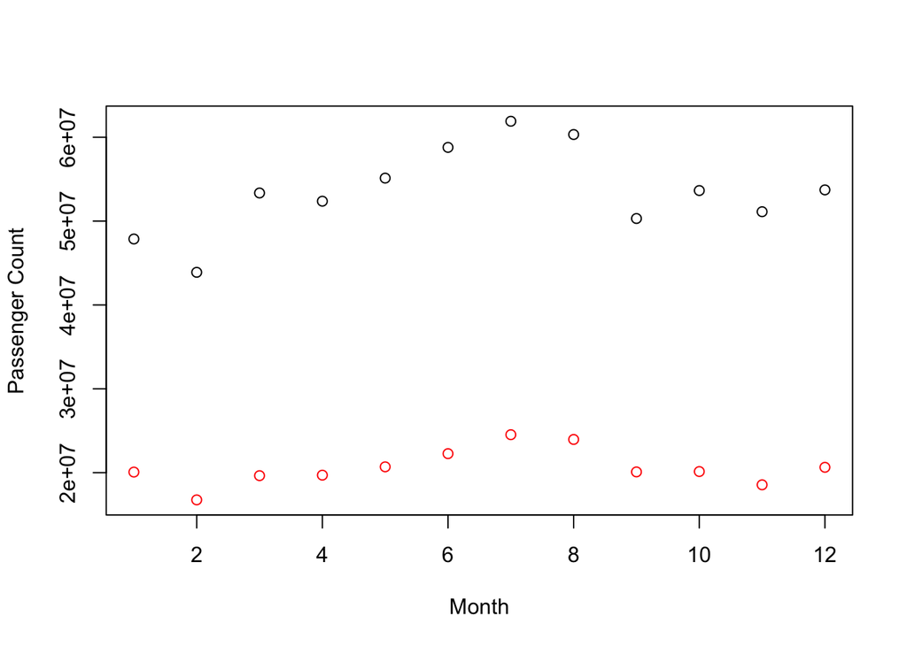

```r
 with(D_I_perM, {plot(Month, Passenger_sum,col = as.factor(Domestic_International), xlab = "Month", ylab = "Passenger Count")
 legend = D_I_perM$Domestic_International})
```

ggplot - Tom Brady International Terminal

```r
TB_Monthwise_Data <- LA_Airport_Mod %>%
  select(Terminal,Year,Month,Passenger_Count) %>%
  filter(Terminal == "Tom_Bradley_International_Terminal") %>%
  group_by(Year,Month) %>%
  summarize(Passenger_sum = sum(Passenger_Count)) %>%
  arrange(Year)

TB_Monthwise_Data
```

```
## # A tibble: 156 x 3
## # Groups:   Year [13]
##     Year Month Passenger_sum
##    <dbl> <dbl>         <dbl>
##  1  2006     1        774680
##  2  2006     2        627417
##  3  2006     3        729157
##  4  2006     4        753692
##  5  2006     5        793194
##  6  2006     6        836075
##  7  2006     7        912846
##  8  2006     8        875999
##  9  2006     9        709762
## 10  2006    10        692199
## # … with 146 more rows
```

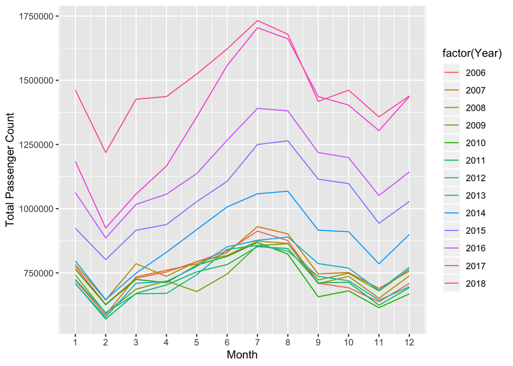

```r
p1 <- ggplot(data = TB_Monthwise_Data) +
  geom_line(mapping = aes(x = Month, y = Passenger_sum,  color = factor(Year)))+
  labs(x = "Month",y = "Total Passenger Count") +
  scale_x_continuous(breaks  = c(1,2,3,4,5,6,7,8,9,10,11,12))

p1
```

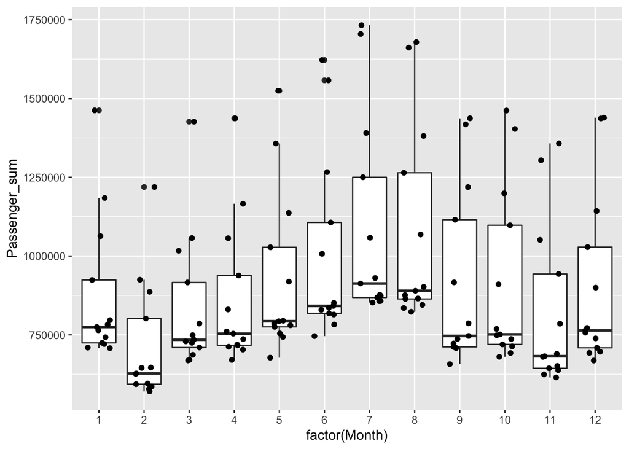

```r
p2 <- ggplot(data = TB_Monthwise_Data, mapping = aes(x=factor(Month), y=Passenger_sum)) +
  geom_boxplot() +
  geom_jitter(width = 0.25)

p2
```

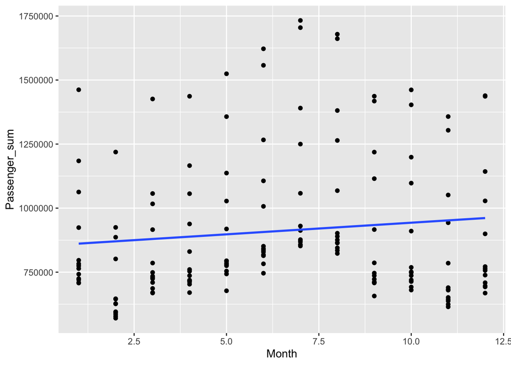

```r
p3 <- ggplot(data = TB_Monthwise_Data, mapping = aes(x = Month, y = Passenger_sum)) +
  geom_point() +
  geom_smooth(method = "lm", se=FALSE)

p3
```

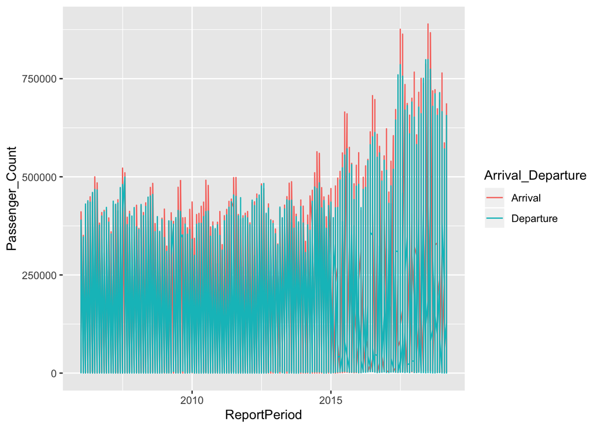

```r
p4 <- ggplot(LA_Airport_Modified, aes(ReportPeriod, Passenger_Count, colour = Arrival_Departure)) +
  geom_line()

p4
```

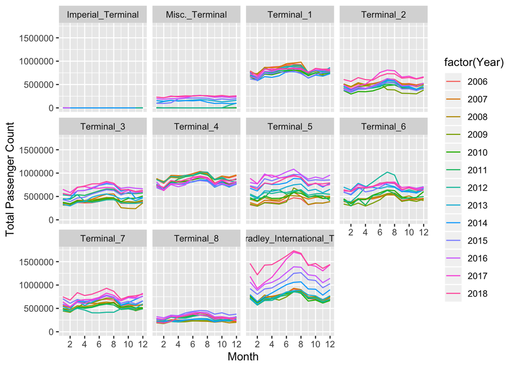

```r
p5 <- ggplot(data = Monthwise_Data) +
  geom_line(mapping = aes(x = Month, y = Passenger_sum,color = factor(Year))) +
  facet_wrap(~ Terminal) +
  labs(x = "Month",y = "Total Passenger Count") +
  scale_x_continuous(breaks  = c(2,4,6,8,10,12))


p5
```

#### Summary

Using ggplot, I have tried to create 5 plots:

1. ggplot + geom_line:

This visualizations displays Month on x axis and Passenger sum on y axis from TB_MOnthwise_data df. Year is displayed with different colors on the plot. As I mentioned in the beginning, I wanted to find patterns in passenger traffic by oberseving it on a monthly basis. We can clearly see that beginning 2006 to 2018, the passenger traffic decreases in february and steadily increases until July-August timeframe and then steadily decreases until november and slightly increases over december.Lowest passenger traffic is observed in february and highest passenger traffic is observed in July-August. Maybe during summer everyone is going on vacations and thats why we see the passenger traffic is highest in Tom Brady International Airport during the peak summer time.

2. ggplot + geom_boxplot + geom_jitter :

This visualizations displays Month on x axis and Passenger sum on y axis from TB_MOnthwise_data df. I have tried to use the boxplot feature with jitter here to observe the Tom Brady International Airport data from 2006- 2018. the jitter feature helps to understand the spread and outliers much more conviniently. We can clearly make out that the median passenger trafic in summer is more than the median during the beginning or end of the year.

3. ggplot+ geom_point + geom_smooth:

I tried to plot the Tom Brady International Terminal data from 2006-2018 using the geom_point and geom_smooth just to try and understand what we can see and interpret. I understand from this visualization that the passenger traffic increases from start to end of a year.

4. ggplot + geom_line:

In this visualization I have used the LA_Airport_Modified df.On the x axis, we have the Report Period and y axis we have the passenger count.The color display Arrival or departures.FRom the visualization, we can understand that the passenger counts have been high for arrivals than those of departures.

5. ggplot + geom_line + facet_wrap:

Using the facet wrap I have tried to visualize the passenger traffic from 2006-2018 for all the 11 terminals in LA International airport on a monthly basis.Tom Bradley international airport has seen a steady increase in passenger traffic over time.